# Escala sobre Crenças e Práticas de Prevenção ao uso de álcool e outras drogas - Relatório das análise

Este relatório objetiva apresentar as análises introdutória do instrumento “Escala de práticas na prevenção do uso de álcool e outras drogas”, que está em fase de desenvolvimento pelo Centro de Referência em Pesquisa, Intervenção e Avaliação em Álcool e Outras Drogas (http://www.ufjf.br/crepeia/).

O instrumento está sendo validado para população de educadores. O objetivo da pesquisa é oferecer uma medida confiável para avaliação das crenças e práticas de educadores de um curso à distância oferecido pela Secretaria Nacional de Políticas sobre Drogas para aproximadamente 10.000 educadores dos estados de Minas Gerais, Rio de Janeiro e Paraná.

Durante todo o processo de desenvolvimento, foram utilizadas ferramentas de código-aberto, para facilitar o re-uso das técnicas e procedimentos desenvolvidos. Todo conteúdo do instrumento e de suas etapas estará disponível para o público no repositório (http://github.com/crepeia/ead-senad). Atualmente, o projeto está hospedado no repositório (http://github.com/henriquepgomide/ead-senad).

Neste relatório são apresentadas, análises da escala com base em uma amostra de 136 educadores-tutores do curso. As análises foram conduzidas através da linguagem de programação R usando os pacotes *car* e *psych*.

## Banco de Dados

O banco de dados da pesquisa, pode ser obtido no seguinte endereço: (https://github.com/henriquepgomide/ead-senad/blob/master/praticasprofissionais_df.csv).

## Resultados

Os resultados são apresentados por tópicos: caracterização da amostra, avaliação descritiva da escala e análise fatorial exploratória.

### Bibliotecas

```r
library(car) # Function Recode
library(psych) # Function Describe
library(xtable) # Function xtable
praticasPro  <- read.csv("praticasprofissionais_df.csv")
## Summing scales to remove NA's
praticasPro$scaleSum  <- rowSums(praticasPro[,21:63])
## Subset completed observations and consented participation
praticasPro  <- subset(praticasPro, subset=praticasPro$termo=="Sim" & praticasPro$estado=="Finalizadas" & !is.na(praticasPro$scaleSum))
```

### Sócio-demográficas

Dos 136, educadores 86,8% eram do sexo feminino e 13,2% do sexo masculino. A idade média da amostra foi de 39,37 anos (DP= 8,45). Aproxidamente 91,2% da amostra possuia como último nível de formação pós-graduação e 8,8% ensino superior completo. O tempo mediano de atuação como professor foi de 10 anos (Distância Interquartílica = 12).

No que se refere ao contato com o tema, aproximadamente 64,2% dos participantes lidaram com usuários de álcool e outras drogas. A maioria dos profissionais disse lidar com usuários na escola 50,5% e 26,8% na família.

#### Idade

```r
idade  <- as.character(praticasPro$idade)
idade[9]  <- "35"; idade[44] <- "29"; idade[69]  <- "31"; idade[111]   <-  42;
praticasPro$idade  <- as.numeric(gsub("anos(.*)", "", idade))
describe(praticasPro$idade) # all
```

```
##   vars   n  mean   sd median trimmed  mad min max range skew kurtosis   se
## 1    1 136 39.37 8.45   38.5   38.96 9.64  25  62    37 0.43    -0.49 0.72
```

```r
by(praticasPro$idade, praticasPro$sexo, describe) #by sex
```

```
## praticasPro$sexo: Feminino
##   vars   n  mean  sd median trimmed  mad min max range skew kurtosis   se
## 1    1 118 38.91 8.5     38   38.34 8.15  26  62    36 0.57    -0.31 0.78
## --------------------------------------------------------
## praticasPro$sexo: Masculino
##   vars  n  mean   sd median trimmed  mad min max range  skew kurtosis  se
## 1    1 18 42.39 7.62     44   42.75 8.15  25  54    29 -0.52    -0.66 1.8
```

#### Sexo

```r
cbind(round(prop.table(table(praticasPro$sexo)),3))
```

```
##            [,1]
## Feminino  0.868
## Masculino 0.132
```

#### Escolaridade

```r
cbind(round(prop.table(table(praticasPro$escolaridade)),3))
```

```
##                           [,1]
## Ensino Superior Completo 0.088
## Pós-graduação            0.912
```

#### Estado Civil

```r
cbind(round(prop.table(table(praticasPro$estadocivil)),3))
```

```
##                 [,1]
## Casado (a)     0.500
## Divorciado (a) 0.132
## Outros         0.081
## Solteiro (a)   0.287
```

#### Tempo de serviço

```r
timeWorking  <- as.character(praticasPro$tempo.atuacao)
praticasPro$timeWorking  <- as.numeric(gsub("anos(.*)", "", timeWorking))
describe(praticasPro$timeWorking)
```

```
##   vars   n  mean   sd median trimmed  mad min max range skew kurtosis   se
## 1    1 123 12.59 8.25     10   11.58 7.41   1  42    41    1     0.63 0.74
```

#### Religião

```r
cbind(round(prop.table(table(praticasPro$religiao)),3))
```

```
##               [,1]
## Católica     0.529
## Espírita     0.169
## Evangélica   0.147
## Outras       0.059
## Sem religião 0.096
```

#### Contato com o tema

```r
cbind(round(prop.table(table(praticasPro$contato.tema)),3))
```

```
##      [,1]
## Não 0.368
## Sim 0.632
```

#### Lida com

```r
cbind(round(prop.table(table(praticasPro$lida.com)),2))
```

```
##     [,1]
## Não 0.36
## Sim 0.64
```

#### Onde lida com

```r
cbind(round(prop.table(table(praticasPro$onde.lida.com)),2))
```

```
##                   [,1]
## Escola            0.51
## Família           0.27
## Outros            0.20
## Serviços de Saúde 0.03
```

### Apresentação dos itens da escala

```r
questions  <- read.csv("praticasprofissionais_questions.csv", col.names = "Itens", header=TRUE)
print(xtable(questions), type="html")
```

|  | Itens |
| --- | --- |
| 1 | Os educadores já estão muito ocupados com suas atividades educacionais para realizarem estratégias de prevenção. |
| 2 | Como professor, sou capaz de mediar a construção colaborativa do conhecimento, e posso contribuir para realizar mudanças sociais. |
| 3 | A responsabilidade de questões de saúde é função do professor. |
| 4 | Como educador, entendo que é papel da escola orientar seus alunos, almejando a construção colaborativa de sua identidade. |
| 5 | Admito ser necessário abordar temas como a promoção de saúde no contexto escolar. |
| 6 | A escola é o principal contexto para realização de ações em saúde e educação para os adolescentes. |
| 7 | Entendo que trabalhar com a prevenção do uso de álcool seja tão importante quanto a prevenção do uso de outras drogas. |
| 8 | Admito que trabalhar com usuários de crack seja mais difícil do que com usuários de outras drogas, pois são mais perigosos. |
| 9 | Acredito que, ações para reduzir o consumo de álcool e outras drogas entre adolescentes ou atrasar o início de seu uso são positivas. |
| 10 | Considero o confronto e o “sermão” como os métodos mais eficazes de abordagem aos usuários de álcool e outras drogas. |
| 11 | Conheço o suficiente sobre as causas dos problemas relacionados à álcool e outras drogas para lidar com um aluno usuário de drogas. |
| 12 | Oriento meus alunos sobre os padrões de consumo de risco relativos ao uso de álcool e outras drogas. |
| 13 | Converso sobre os fatores de risco e proteção para o uso de álcool e outras drogas, porque os adolescentes não têm a capacidade de avaliação dos riscos. |
| 14 | Realizo práticas de prevenção aos problemas relacionados ao uso de álcool e outras drogas na escola. |
| 15 | Sou ator chave de articulação e parcerias para a implementação de programas de prevenção ao uso de álcool e outras drogas na escola. |
| 16 | Creio que a escola seja capaz de identificar possíveis ações de fortalecimento da rede de apoio ao usuário de álcool e outras drogas. |
| 17 | Considero-me preparado para uma avaliação das redes sociais dos adolescentes usuários de álcool e outras drogas. |
| 18 | Aceito e trabalho com a repressão ao uso de álcool e outras drogas. |
| 19 | Na minha escola, crio ações de parceria com as redes de proteção ao adolescente em situação de vulnerabilidade social. |
| 20 | A escola é um ambiente propício para o desenvolvimento de técnicas de prevenção ao uso de álcool e outras drogas. |
| 21 | Não existe tempo suficiente durante as aulas para perguntar aos alunos sobre seu consumo de álcool e outras drogas e problemas de saúde relacionados. |
| 22 | Procuro participar das estratégias de criação e implementação e de políticas públicas sobre álcool e outras drogas direcionadas à educação. |
| 23 | Sou capaz de preparar os meus alunos para se tornarem multiplicadores de ações de prevenção do uso de álcool e outras drogas na escola. |
| 24 | Crio espaços de discussões sobre o tema álcool e outras drogas com os alunos. |
| 25 | Avalio o histórico familiar de problemas com álcool e outras drogas dos meus alunos. |
| 26 | Posso manter relações de confiança e apoio com os alunos sem abrir mão de minha autoridade em sala. |
| 27 | Creio que minhas práticas devam ser baseadas no autoritarismo para que previnam o uso de álcool e outras drogas na escola. |
| 28 | Os educadores não têm habilidades interpessoais para conversar e orientar seus alunos sobre o consumo de álcool e outras drogas. |
| 29 | Minha formação acadêmico/ profissional sobre os problemas relacionados à álcool e outras drogas é adequada. |
| 30 | Como parte do meu dia-a-dia na escola, pergunto aos meus alunos sobre seu consumo e sua história de problemas relacionados ao uso de álcool e outras drogas. |
| 31 | Penso que os alunos poderão ficar irritados se o educador lhe perguntar sobre seu consumo de álcool e outras drogas. |
| 32 | A prevenção do uso de álcool e outras drogas na escola não deve fazer parte do projeto político pedagógico. |
| 33 | Eu crio um ambiente propício à interação entre professor-aluno a fim de favorecer as estratégias de prevenção ao uso de álcool e outras drogas. |
| 34 | Posso aconselhar apropriadamente meus alunos sobre o consumo de álcool e outras drogas e seu efeito. |
| 35 | Oriento de forma adequada os alunos a diminuir ou a parar o consumo de álcool e outras drogas. |
| 36 | Demonstrar aos estudantes minhas preocupações sobre os riscos do uso de álcool e outras drogas reduzirá seu consumo. |
| 37 | Eu me sinto seguro para expor minhas preocupações profissionais sobre o padrão de uso de álcool e outras drogas e os riscos associados à saúde dos meus alunos. |
| 38 | Considero que não tenho como ajudar os alunos usuários de álcool e outras drogas. |
| 39 | Em geral, os educadores não podem ajudar seus alunos na redução do consumo de álcool e outras drogas. |
| 40 | Não sei como devo abordar os alunos para auxiliá-los na redução do consumo de álcool e outras drogas. |
| 41 | Para obter informações sobre os riscos e problemas relacionados ao uso de álcool e outras drogas, faço perguntas aos próprios alunos. |
| 42 | Não sei o que perguntar aos alunos para obter informações sobre o consumo de álcool e outras drogas. |
| 43 | Suponho que práticas para reduzir o uso de álcool e outras drogas entre adolescentes são benéficas. |

### Itens

```r
fullScale  <- praticasPro[,21:63] # Versão completa da escala
describe(fullScale, skew=FALSE)
```

```
##       vars   n mean   sd median trimmed  mad min max range   se
## pp001    1 136 1.91 0.91      2    1.79 1.48   1   4     3 0.08
## pp002    2 136 4.48 0.58      5    4.53 0.00   3   5     2 0.05
## pp003    3 136 2.79 0.94      3    2.80 1.48   1   5     4 0.08
## pp004    4 136 4.35 0.56      4    4.36 0.00   3   5     2 0.05
## pp005    5 136 4.46 0.64      5    4.52 0.00   1   5     4 0.06
## pp006    6 136 3.97 0.84      4    4.05 1.48   2   5     3 0.07
## pp007    7 136 4.54 0.54      5    4.57 0.00   3   5     2 0.05
## pp008    8 136 2.88 0.89      3    2.91 1.48   1   5     4 0.08
## pp009    9 136 4.20 0.74      4    4.28 0.00   2   5     3 0.06
## pp010   10 136 1.77 0.73      2    1.69 1.48   1   4     3 0.06
## pp011   11 136 2.44 0.97      2    2.41 1.48   1   5     4 0.08
## pp012   12 136 3.72 0.80      4    3.78 0.00   1   5     4 0.07
## pp013   13 136 3.24 1.03      3    3.22 1.48   1   5     4 0.09
## pp014   14 136 3.43 0.93      4    3.45 1.48   1   5     4 0.08
## pp015   15 136 3.38 1.03      3    3.39 1.48   1   5     4 0.09
## pp016   16 136 4.14 0.70      4    4.21 0.00   2   5     3 0.06
## pp017   17 136 3.15 0.95      3    3.14 1.48   1   5     4 0.08
## pp018   18 136 3.17 1.06      3    3.20 1.48   1   5     4 0.09
## pp019   19 136 3.13 0.98      3    3.18 1.48   1   5     4 0.08
## pp020   20 136 4.35 0.61      4    4.40 0.00   3   5     2 0.05
## pp021   21 136 2.32 0.98      2    2.25 1.48   1   5     4 0.08
## pp022   22 136 3.76 0.80      4    3.81 0.00   2   5     3 0.07
## pp023   23 136 3.81 0.73      4    3.82 0.00   2   5     3 0.06
## pp024   24 136 3.82 0.87      4    3.91 0.00   1   5     4 0.07
## pp025   25 136 3.51 0.89      4    3.54 0.74   1   5     4 0.08
## pp026   26 136 4.30 0.67      4    4.36 0.00   1   5     4 0.06
## pp027   27 136 1.54 0.67      1    1.46 0.00   1   5     4 0.06
## pp028   28 136 1.96 0.88      2    1.86 1.48   1   5     4 0.08
## pp029   29 136 2.62 1.00      2    2.59 1.48   1   5     4 0.09
## pp030   30 136 3.21 0.93      3    3.22 1.48   1   5     4 0.08
## pp031   31 136 2.35 0.82      2    2.34 1.48   1   4     3 0.07
## pp032   32 136 1.73 0.99      1    1.53 0.00   1   5     4 0.09
## pp033   33 136 3.72 0.80      4    3.74 0.00   1   5     4 0.07
## pp034   34 136 3.82 0.72      4    3.83 0.00   1   5     4 0.06
## pp035   35 136 3.61 0.81      4    3.62 1.48   1   5     4 0.07
## pp036   36 136 3.10 0.89      3    3.12 1.48   1   5     4 0.08
## pp037   37 136 3.61 0.89      4    3.65 0.00   1   5     4 0.08
## pp038   38 136 1.96 0.82      2    1.89 1.48   1   4     3 0.07
## pp039   39 136 1.86 0.83      2    1.75 1.48   1   5     4 0.07
## pp040   40 136 2.47 0.91      2    2.45 1.48   1   5     4 0.08
## pp041   41 136 3.16 0.87      3    3.16 1.48   1   5     4 0.07
## pp042   42 136 2.26 0.87      2    2.19 0.00   1   5     4 0.07
## pp043   43 136 4.30 0.75      4    4.42 1.48   1   5     4 0.06
```

### Correlation Matrix

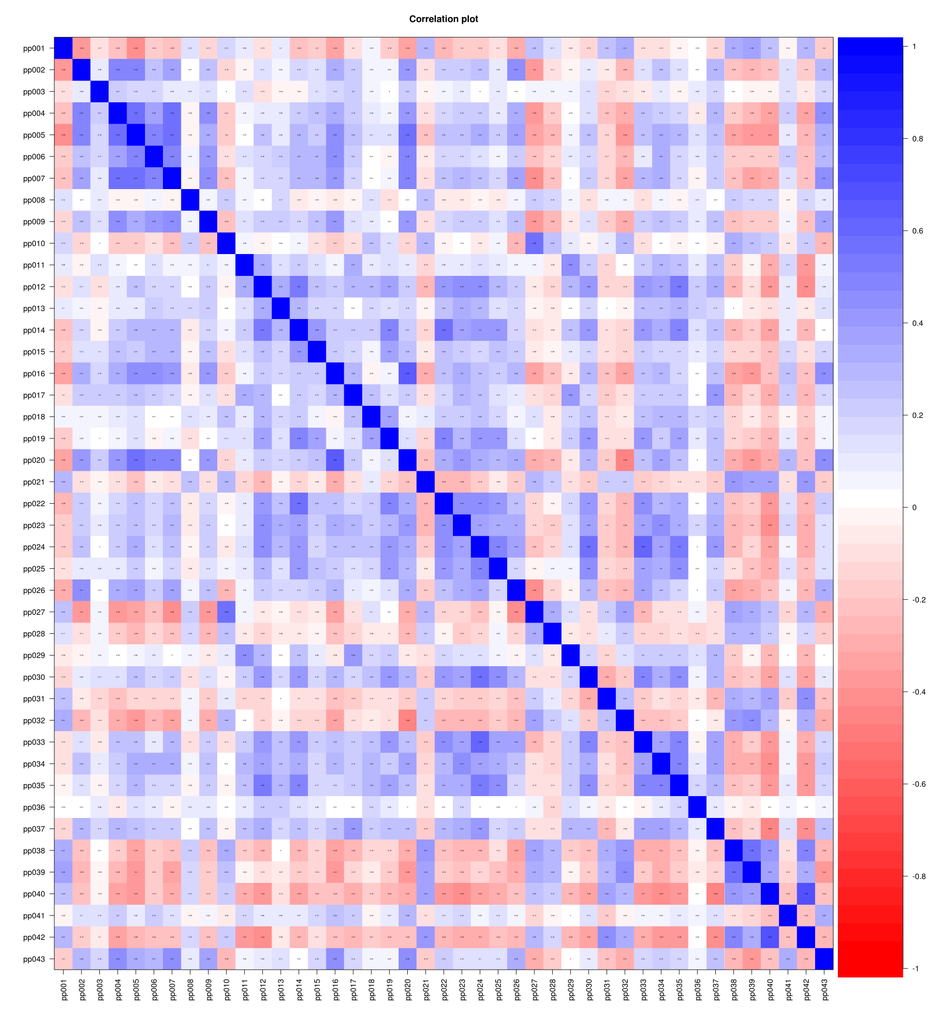

```r
cor.plot(cor(fullScale, method="kendal", use="complete.obs"), numbers= TRUE)
```

### Crobach’s alfa

Método - O alfa de Cronbach foi utilizado como um indicador da confiabilidade da escala.

Resultado - O valor alfa de Cronbach para escala com 43 itens foi de 0.90 (IC_{95%} = 0,88 - 0,93).

Referência - Cronbach, L.J. (1951) Coefficient alpha and the internal strucuture of tests. Psychometrika, 16, 297-334.

```r
alpha(fullScale)
```

```
##
## Reliability analysis
## Call: alpha(x = fullScale)
##
##   raw_alpha std.alpha G6(smc) average_r S/N   ase mean   sd
##        0.9      0.91    0.95      0.19  10 0.015  3.7 0.38
##
##  lower alpha upper     95% confidence boundaries
## 0.88 0.9 0.93
##
##  Reliability if an item is dropped:
##        raw_alpha std.alpha G6(smc) average_r  S/N alpha se
## pp001-      0.90      0.91    0.95      0.19  9.9    0.015
## pp002       0.90      0.91    0.95      0.19  9.9    0.015
## pp003       0.91      0.91    0.95      0.20 10.3    0.014
## pp004       0.90      0.91    0.95      0.19  9.8    0.015
## pp005       0.90      0.91    0.95      0.19  9.8    0.015
## pp006       0.90      0.91    0.95      0.19  9.8    0.015
## pp007       0.90      0.91    0.95      0.19  9.8    0.015
## pp008-      0.91      0.91    0.95      0.20 10.3    0.014
## pp009       0.90      0.91    0.95      0.19  9.9    0.015
## pp010-      0.90      0.91    0.95      0.19 10.2    0.015
## pp011       0.90      0.91    0.95      0.19 10.0    0.015
## pp012       0.90      0.91    0.95      0.19  9.7    0.015
## pp013       0.90      0.91    0.95      0.19 10.1    0.015
## pp014       0.90      0.91    0.95      0.19  9.7    0.015
## pp015       0.90      0.91    0.95      0.19  9.9    0.015
## pp016       0.90      0.91    0.95      0.19  9.7    0.015
## pp017       0.90      0.91    0.95      0.19  9.8    0.015
## pp018       0.91      0.91    0.95      0.19 10.2    0.015
## pp019       0.90      0.91    0.95      0.19  9.9    0.015
## pp020       0.90      0.91    0.95      0.19  9.6    0.015
## pp021-      0.90      0.91    0.95      0.19  9.9    0.015
## pp022       0.90      0.91    0.95      0.19  9.7    0.015
## pp023       0.90      0.91    0.95      0.19  9.7    0.015
## pp024       0.90      0.91    0.95      0.19  9.7    0.015
## pp025       0.90      0.91    0.95      0.19  9.9    0.015
## pp026       0.90      0.91    0.95      0.19  9.8    0.015
## pp027-      0.90      0.91    0.95      0.19 10.0    0.015
## pp028-      0.90      0.91    0.95      0.19 10.0    0.015
```

[output cut: 92 more lines]

```
## pp029 0.10 0.40 0.31 0.14 0.04    0
## pp030 0.03 0.19 0.38 0.33 0.07    0
## pp031 0.14 0.45 0.33 0.08 0.00    0
## pp032 0.51 0.35 0.06 0.04 0.04    0
## pp033 0.01 0.04 0.30 0.51 0.14    0
## pp034 0.01 0.03 0.24 0.60 0.13    0
## pp035 0.01 0.07 0.35 0.46 0.12    0
## pp036 0.04 0.20 0.43 0.29 0.04    0
## pp037 0.01 0.11 0.24 0.51 0.12    0
## pp038 0.31 0.47 0.18 0.04 0.00    0
## pp039 0.35 0.49 0.10 0.04 0.01    0
## pp040 0.12 0.45 0.29 0.12 0.01    0
## pp041 0.01 0.22 0.40 0.32 0.04    0
## pp042 0.16 0.52 0.23 0.07 0.01    0
## pp043 0.01 0.02 0.07 0.47 0.43    0
```

## Análise Fatorial

### KMO - Adequação da amostra

```r
KMO(fullScale)
```

```
## Kaiser-Meyer-Olkin factor adequacy
## Call: KMO(r = fullScale)
## Overall MSA =  0.81
## MSA for each item =
## pp001 pp002 pp003 pp004 pp005 pp006 pp007 pp008 pp009 pp010 pp011 pp012
##  0.75  0.82  0.53  0.79  0.80  0.81  0.92  0.59  0.82  0.64  0.78  0.86
## pp013 pp014 pp015 pp016 pp017 pp018 pp019 pp020 pp021 pp022 pp023 pp024
##  0.74  0.80  0.77  0.87  0.73  0.59  0.83  0.90  0.79  0.82  0.86  0.88
## pp025 pp026 pp027 pp028 pp029 pp030 pp031 pp032 pp033 pp034 pp035 pp036
##  0.82  0.82  0.75  0.74  0.73  0.90  0.82  0.71  0.87  0.85  0.87  0.50
## pp037 pp038 pp039 pp040 pp041 pp042 pp043
##  0.83  0.80  0.83  0.82  0.62  0.78  0.78
```

Referências

- H.~F. Kaiser. (1970) A second generation little jiffy. Psychometrika, 35(4):401–415.
- Bartlett, M. S. (1937). Properties of sufficiency and statistical tests. Proceedings of the Royal Society of London Series A 160, 268–282.

Usando o grafico de autovalores, foram retidos dois fatores. Como criterio, escolheu-se o o ponto de quebra do *Scree plot*.

### Esfericidade

```r
bartlett.test(fullScale)
```

```
##
##  Bartlett test of homogeneity of variances
##
## data:  fullScale
## Bartlett's K-squared = 300.9, df = 42, p-value < 2.2e-16
```

### Análise paralela

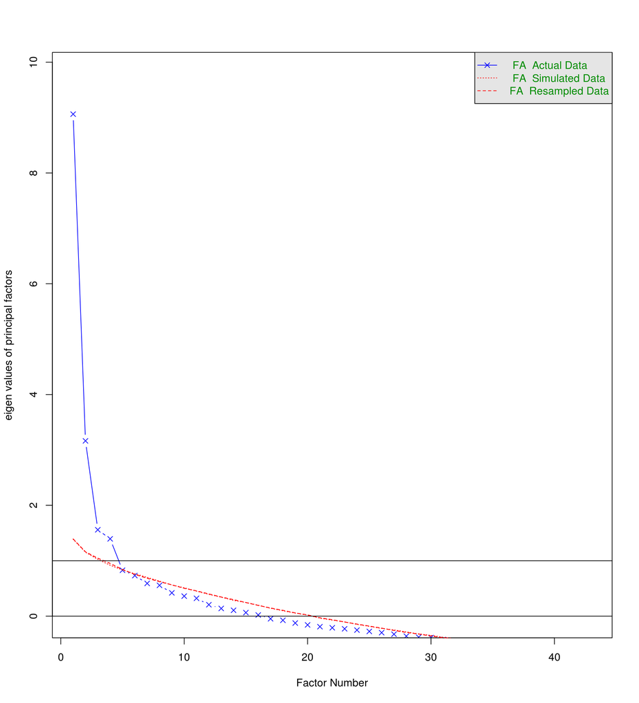

```
## Parallel analysis suggests that the number of factors =  4  and the number of components =  4
```

```r
fa.parallel(fullScale, fm="minres", fa="fa", main="")
```

O número de fatores a serem retidos foi determinado pela análise do gráfico *Scree Plot*. Como é esperado que os fatores sejam correlacionados por serem habilidades semelhantes, foi utilizada uma rotação oblíqua *Oblimin* e o método de fatoração foi o de *mínimos resíduos*. Devido à natureza politômica dos itens, a análise fatorial exploratória foi realizada com correlações policóricas.

A porcentagem de variância explicada foi de 33%. A correlação entre os fatores foi de 0,45.

### Tabela com itens

```r
faAll <- fa.poly(fullScale, nfactors = 2, rotate = "oblimin", fm="minres")
```

```
## The items do not have an equal number of response alternatives, global set to FALSE
```

```r
print.psych(faAll, digits = 2, cut = .3)
```

```
## Factor Analysis using method =  minres
## Call: fa.poly(x = fullScale, nfactors = 2, rotate = "oblimin", fm = "minres")
## Standardized loadings (pattern matrix) based upon correlation matrix
##         MR1   MR2    h2   u2 com
## pp001 -0.49       0.282 0.72 1.0
## pp002  0.65       0.414 0.59 1.0
## pp003             0.026 0.97 1.2
## pp004  0.71       0.492 0.51 1.0
## pp005  0.73       0.575 0.42 1.0
## pp006  0.60       0.358 0.64 1.0
## pp007  0.75       0.574 0.43 1.0
## pp008             0.016 0.98 1.2
## pp009  0.63       0.390 0.61 1.0
## pp010 -0.56       0.256 0.74 1.2
## pp011        0.39 0.119 0.88 1.4
## pp012        0.68 0.456 0.54 1.0
## pp013        0.38 0.143 0.86 1.0
## pp014        0.65 0.435 0.56 1.0
## pp015        0.30 0.197 0.80 1.8
## pp016  0.70       0.515 0.49 1.0
## pp017        0.33 0.172 0.83 1.3
## pp018        0.49 0.194 0.81 1.3
## pp019        0.71 0.413 0.59 1.2
## pp020  0.70       0.593 0.41 1.1
## pp021 -0.31       0.204 0.80 1.8
## pp022        0.65 0.467 0.53 1.0
## pp023        0.53 0.403 0.60 1.3
## pp024        0.61 0.467 0.53 1.1
## pp025        0.55 0.310 0.69 1.0
## pp026  0.54       0.357 0.64 1.1
## pp027 -0.71       0.446 0.55 1.0
## pp028 -0.44       0.200 0.80 1.0
## pp029        0.47 0.177 0.82 1.5
## pp030        0.67 0.445 0.55 1.0
## pp031             0.185 0.82 1.9
## pp032 -0.60       0.393 0.61 1.0
## pp033        0.59 0.432 0.57 1.1
## pp034        0.39 0.334 0.67 1.8
## pp035        0.61 0.403 0.60 1.0
## pp036             0.021 0.98 1.2
```

[output cut: 26 more lines]

```
## The root mean square of the residuals (RMSR) is  0.07
## The df corrected root mean square of the residuals is  0.08
##
## The harmonic number of observations is  136 with the empirical chi square  1332  with prob <  2.8e-27
## The total number of observations was  136  with MLE Chi Square =  1237  with prob <  1.2e-19
##
## Tucker Lewis Index of factoring reliability =  0.761
## RMSEA index =  0.073  and the 90 % confidence intervals are  0.054 0.068
## BIC =  -2782
## Fit based upon off diagonal values = 0.93
## Measures of factor score adequacy
##                                                 MR1  MR2
## Correlation of scores with factors             0.97 0.95
## Multiple R square of scores with factors       0.93 0.91
## Minimum correlation of possible factor scores  0.86 0.82
```

### Versão com itens com boas cargas fatoriais

```r
v1Scale  <- subset(fullScale, select = -c(3,8,15,31,36,41)) # Criação da escala com itens de cargas fatoriais boas
faAll <- fa.poly(v1Scale, nfactors = 2, rotate = "oblimin", fm="minres")
```

```
## The items do not have an equal number of response alternatives, global set to FALSE
```

```r
print.psych(faAll, digits=2, cut=0.3)
```

```
## Factor Analysis using method =  minres
## Call: fa.poly(x = v1Scale, nfactors = 2, rotate = "oblimin", fm = "minres")
## Standardized loadings (pattern matrix) based upon correlation matrix
##         MR1   MR2   h2   u2 com
## pp001 -0.49       0.28 0.72 1.0
## pp002  0.66       0.42 0.58 1.0
## pp004  0.70       0.48 0.52 1.0
## pp005  0.74       0.58 0.42 1.0
## pp006  0.60       0.35 0.65 1.0
## pp007  0.76       0.58 0.42 1.0
## pp009  0.63       0.39 0.61 1.0
## pp010 -0.56       0.26 0.74 1.2
## pp011        0.38 0.12 0.88 1.4
## pp012        0.67 0.45 0.55 1.0
## pp013        0.38 0.14 0.86 1.0
## pp014        0.64 0.43 0.57 1.0
## pp016  0.70       0.51 0.49 1.0
## pp017        0.33 0.17 0.83 1.3
## pp018        0.49 0.19 0.81 1.3
## pp019        0.71 0.41 0.59 1.2
## pp020  0.70       0.59 0.41 1.1
## pp021 -0.31       0.20 0.80 1.8
## pp022        0.66 0.47 0.53 1.0
## pp023        0.53 0.40 0.60 1.3
## pp024        0.62 0.48 0.52 1.1
## pp025        0.55 0.31 0.69 1.0
## pp026  0.54       0.36 0.64 1.1
## pp027 -0.71       0.45 0.55 1.0
## pp028 -0.45       0.20 0.80 1.0
## pp029        0.46 0.17 0.83 1.5
## pp030        0.68 0.45 0.55 1.0
## pp032 -0.60       0.39 0.61 1.0
## pp033        0.60 0.44 0.56 1.1
## pp034        0.40 0.34 0.66 1.8
## pp035        0.61 0.41 0.59 1.0
## pp037        0.45 0.30 0.70 1.3
## pp038 -0.44       0.37 0.63 1.7
## pp039 -0.57       0.39 0.61 1.1
## pp040       -0.51 0.43 0.57 1.4
## pp042       -0.45 0.39 0.61 1.7
```

[output cut: 20 more lines]

```
## The root mean square of the residuals (RMSR) is  0.07
## The df corrected root mean square of the residuals is  0.08
##
## The harmonic number of observations is  136 with the empirical chi square  940.4  with prob <  3.4e-18
## The total number of observations was  136  with MLE Chi Square =  963.3  with prob <  4.3e-20
##
## Tucker Lewis Index of factoring reliability =  0.777
## RMSEA index =  0.078  and the 90 % confidence intervals are  0.06 0.075
## BIC =  -1950
## Fit based upon off diagonal values = 0.94
## Measures of factor score adequacy
##                                                 MR1  MR2
## Correlation of scores with factors             0.96 0.95
## Multiple R square of scores with factors       0.93 0.91
## Minimum correlation of possible factor scores  0.86 0.82
```

#### Diagrama com fatores

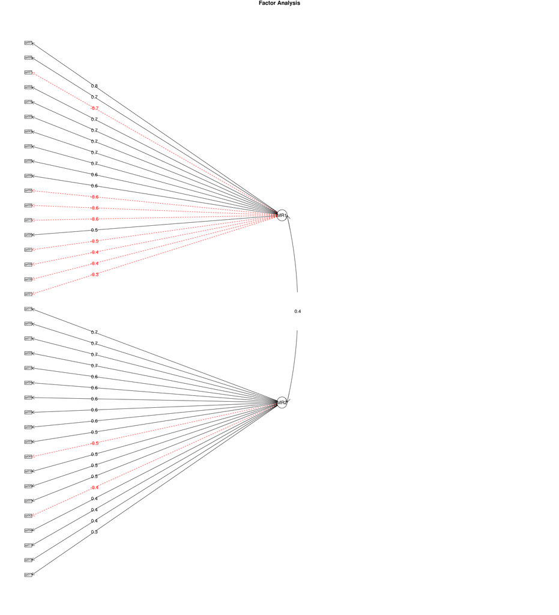

```r
fa.diagram(faAll)
```